# Assignment 4

In this assignment, you'll combine the assignment 3 data set with nutrition data from the [USDA Food Composition Databases](https://ndb.nal.usda.gov/ndb/search/list). The CSV file `fresh.csv` contains the fresh fruits and vegetables data you extracted in assignment 3.

The USDA Food Composition Databases have a [documented](https://ndb.nal.usda.gov/ndb/doc/index) web API that returns data in JSON format . You need a key in order to use the API. Only 1000 requests are allowed per hour, so it would be a good idea to use [caching](https://pypi.python.org/pypi/requests-cache).

[Sign up for an API key here](https://api.data.gov/signup/). The key will work with any Data.gov API. You may need the key again later in the quarter, so make sure you save it.

These modules may be useful:

- [requests](http://docs.python-requests.org/en/master/user/quickstart/)
- [requests_cache](https://pypi.python.org/pypi/requests-cache)
- [urlparse](https://docs.python.org/2/library/urlparse.html)
- [pandas](http://pandas.pydata.org/pandas-docs/stable/)

**Exercise 1.1.** Read the [search request documentation](https://ndb.nal.usda.gov/ndb/doc/apilist/API-SEARCH.md), then write a function called `ndb_search()` that makes a search request. The function should accept the search term as an argument. The function should return the search result items as a list (for 0 items, return an empty list).

Note that the search url is: `https://api.nal.usda.gov/ndb/search`

As an example, a search for `"quail eggs"` should return this list:

```
[{u'ds': u'BL',
  u'group': u'Branded Food Products Database',
  u'name': u'CHAOKOH, QUAIL EGG IN BRINE, UPC: 044738074186',
  u'ndbno': u'45094707',
  u'offset': 0},
 {u'ds': u'BL',
  u'group': u'Branded Food Products Database',
  u'name': u'L&W, QUAIL EGGS, UPC: 024072000256',
  u'ndbno': u'45094890',
  u'offset': 1},
 {u'ds': u'BL',
  u'group': u'Branded Food Products Database',
  u'name': u'BUDDHA, QUAIL EGGS IN BRINE, UPC: 761934535098',
  u'ndbno': u'45099560',
  u'offset': 2},
 {u'ds': u'BL',
  u'group': u'Branded Food Products Database',
  u'name': u'GRAN SABANA, QUAIL EGGS, UPC: 819140010103',
  u'ndbno': u'45169279',
  u'offset': 3},
 {u'ds': u'BL',
  u'group': u'Branded Food Products Database',
  u'name': u"D'ARTAGNAN, QUAIL EGGS, UPC: 736622102630",
  u'ndbno': u'45178254',
  u'offset': 4},
 {u'ds': u'SR',
  u'group': u'Dairy and Egg Products',
  u'name': u'Egg, quail, whole, fresh, raw',
  u'ndbno': u'01140',
  u'offset': 5}]
```

As usual, make sure you document and test your function.

```python
from urllib2 import Request, urlopen
import urllib
import pandas as pd
import json
from matplotlib import pyplot as plt
plt.style.use('ggplot')
%matplotlib inline
import pandas as pd
key = "mjWZcBRPxX4bM0YEmCoLmpablBzxRy5j7dM1HGSF"

#Function to make a search request
def ndb_search(search, key):
    #Encoding characters to work in url
    search = urllib.quote(search)
    fresh_uri = "https://api.nal.usda.gov/ndb/search/?format=json&q={}&max=25&offset=0&api_key={}".format(search, key)
    request = Request(fresh_uri)
    response = urlopen(request)
    rr = response.read()
    js = json.loads(rr) #Convert from str into json object
    return js['list']['item']

#test
search = ndb_search("quail eggs", key)
search
```

```
[{u'ds': u'BL',
  u'group': u'Branded Food Products Database',
  u'name': u'CHAOKOH, QUAIL EGG IN BRINE, UPC: 044738074186',
  u'ndbno': u'45094707',
  u'offset': 0},
 {u'ds': u'BL',
  u'group': u'Branded Food Products Database',
  u'name': u'L&W, QUAIL EGGS, UPC: 024072000256',
  u'ndbno': u'45094890',
  u'offset': 1},
 {u'ds': u'BL',
  u'group': u'Branded Food Products Database',
  u'name': u'BUDDHA, QUAIL EGGS IN BRINE, UPC: 761934535098',
  u'ndbno': u'45099560',
  u'offset': 2},
 {u'ds': u'BL',
  u'group': u'Branded Food Products Database',
  u'name': u'GRAN SABANA, QUAIL EGGS, UPC: 819140010103',
  u'ndbno': u'45169279',
  u'offset': 3},
 {u'ds': u'BL',
  u'group': u'Branded Food Products Database',
  u'name': u"D'ARTAGNAN, QUAIL EGGS, UPC: 736622102630",
  u'ndbno': u'45178254',
  u'offset': 4},
 {u'ds': u'SR',
  u'group': u'Dairy and Egg Products',
  u'name': u'Egg, quail, whole, fresh, raw',
  u'ndbno': u'01140',
  u'offset': 5}]
```

**Exercise 1.2.** Use your search function to get NDB numbers for the foods in the `fresh.csv` file. It's okay if you don't get an NDB number for every food, but try to come up with a strategy that gets most of them. Discuss your strategy in a short paragraph.

Hints:

- The foods are all raw and unbranded.
- You can test search terms with the [online search page](https://ndb.nal.usda.gov/ndb/search/list).
- You can convert the output of `ndb_search()` to a data frame with `pd.DataFrame()`.
- The string methods for [Python](https://docs.python.org/2/library/stdtypes.html#string-methods) and [Pandas](http://pandas.pydata.org/pandas-docs/stable/text.html#method-summary) are useful here. It's okay if you use *simple* regular expressions in the Pandas methods, although this exercise can be solved without them.
- You can merge data frames that have a column in common with `pd.merge()`.

*Discussion of Search function:*

```python
fresh = pd.read_csv("fresh.csv")
#Subsets to column with food names and turns it into a list
food = fresh['food'].values.tolist()

#This function loops past Branded products until it gets to an entry that is a raw fruit or vegetable
#It takes in search return groups and outputs the index of search return where we see a fruit or vegetable
def branded(search_return):
    return filter(lambda d: d['group'] == "Vegetables and Vegetable Products" or d['group'] == "Fruits and Fruit Juices", search_return)

search_return = ndb_search("tangerines", key)

#test print search_return
print branded(search_return)
```

```
[{u'ndbno': u'09218', u'group': u'Fruits and Fruit Juices', u'name': u'Tangerines, (mandarin oranges), raw', u'ds': u'SR', u'offset': 5}, {u'ndbno': u'09221', u'group': u'Fruits and Fruit Juices', u'name': u'Tangerine juice, raw', u'ds': u'SR', u'offset': 6}, {u'ndbno': u'09223', u'group': u'Fruits …
```

```python
#Creates blank list for ndbno to be stored
ndbnos = []

#for loop to search through every produce name in the file
def get_ndb(food):
    for i in range(len(food)):
        if food[i] == "kiwi":
            food[i]+=str("fruit raw")
        food[i]+=str(" raw")
        food[i] = str.replace(food[i], "_", " ")
        search_return = ndb_search(food[i], key)

        #If the first entry returned by the search function is a branded item, a new function must be called to loop past these entries
        if search_return[0]['group'] == "Branded Food Products Database":
            nbdno = branded(search_return)[0]['ndbno']

        else:
            nbdno = search_return[0]['ndbno']
        ndbnos.append(nbdno)
    return ndbnos

ndbnos = get_ndb(food)

#removes preceding u's:

for i in range(len(ndbnos)):
    r = str((ndbnos[i].split(u"-")[0]))
    ndbnos[i] = r
ndbnos
```

```
['09326',
 '09181',
 '09221',
 '09316',
 '09279',
 '09201',
 '09302',
 '09286',
 '09266',
 '09021',
 '09184',
 '09226',
 '09148',
 '09276',
 '09040',
 '09003',
 '09236',
 '09191',
 '09252',
 '09117',
 '09042',
 '09129',
 '09050',
 '09176',
 '11011',
 '11206',
 '11206',
 '11252',
 '11282',
 '11568',
 '11270',
 '11362',
 '11161',
 '11052',
 '11482',
 '11821',
 '11503',
 '11503',
 '11507',
 '11475',
 '11429',
 '11485',
 '09038',
 '11233',
 '11226',
 '11278',
 '11333',
 '11098',
 '11900']
```

```python
#combines ndb numbers and fruit names into one data frame
names = fresh['food'].values.tolist()
all_produce = pd.DataFrame(
    {'ndbno': ndbnos,
     'fruit name': names
    })
all_produce.head()
```

|  | fruit name | ndbno |
| --- | --- | --- |
| 0 | watermelon | 09326 |
| 1 | cantaloupe | 09181 |
| 2 | tangerines | 09221 |
| 3 | strawberries | 09316 |
| 4 | plums | 09279 |

**Exercise 1.3.** Read the [food reports V2 documentation](https://ndb.nal.usda.gov/ndb/doc/apilist/API-FOOD-REPORTV2.md), then write a function called `ndb_report()` that requests a *basic* food report. The function should accept the NDB number as an argument and return the list of nutrients for the food.

Note that the report url is: `https://api.nal.usda.gov/ndb/V2/reports`

For example, for `"09279"` (raw plums) the first element of the returned list should be:

```
{u'group': u'Proximates',
 u'measures': [{u'eqv': 165.0,
   u'eunit': u'g',
   u'label': u'cup, sliced',
   u'qty': 1.0,
   u'value': u'143.93'},
  {u'eqv': 66.0,
   u'eunit': u'g',
   u'label': u'fruit (2-1/8" dia)',
   u'qty': 1.0,
   u'value': u'57.57'},
  {u'eqv': 151.0,
   u'eunit': u'g',
   u'label': u'NLEA serving',
   u'qty': 1.0,
   u'value': u'131.72'}],
 u'name': u'Water',
 u'nutrient_id': u'255',
 u'unit': u'g',
 u'value': u'87.23'}
```

Be sure to document and test your function.

```python
#Gets nutrition data
def ndb_report(key, ndbno):
    fresh_uri = "https://api.nal.usda.gov/ndb/V2/reports/?ndbno={}&type=b&format=json&api_key={}".format(ndbno, key)
    request = Request(fresh_uri)
    response = urlopen(request)
    rr = response.read()
    js = json.loads(rr) #Convert from str into json object
    return js['foods'][0]['food']['nutrients']

#Test function
table = ndb_report(key, "11333")
table[0:10]
```

[output not shown]

[output cut: 395 more lines]

[output not shown]

**Exercise 1.4.** Which foods provide the best combination of price, yield, and nutrition? You can use kilocalories as a measure of "nutrition" here, but more a detailed analysis is better. Use plots to support your analysis.

```python
def format_data(table):
    x = [table[1]['value'], table[2]['value'], table[1]['name'], table[2]['name']]
    return x

#Here I modify ndb_report() to include ndbnos with the nutrition for Energy in kcals

def ndb_report_mod(key, ndbno):
    fresh_uri = "https://api.nal.usda.gov/ndb/V2/reports/?ndbno={}&type=b&format=json&api_key={}".format(ndbno, key)
    request = Request(fresh_uri)
    response = urlopen(request)
    rr = response.read()
    js = json.loads(rr) #Convert from str into json object

    #subsets json output to only include first row of returned nutritional content
    clean = format_data(js['foods'][0]['food']['nutrients'])
    #add in column for ndbno
    clean.insert(0, ndbno)
    return clean

#Test function
table = ndb_report_mod(key, "09279")
table
```

```
['09279', u'46', u'0.70', u'Energy', u'Protein']
```

```python
#create table for all produce

all_rows = []
for i in range(len(all_produce)):
    all_rows.append(ndb_report_mod(key,all_produce['ndbno'][i]))
all_rows[0:10]
```

```
[['09326', u'30', u'0.61', u'Energy', u'Protein'],
 ['09181', u'34', u'0.84', u'Energy', u'Protein'],
 ['09221', u'43', u'0.50', u'Energy', u'Protein'],
 ['09316', u'32', u'0.67', u'Energy', u'Protein'],
 ['09279', u'46', u'0.70', u'Energy', u'Protein'],
 ['09201', u'49', u'1.04', u'Energy', u'Protein'],
 ['09302', u'52', u'1.20', u'Energy', u'Protein'],
 ['09286', u'83', u'1.67', u'Energy', u'Protein'],
 ['09266', u'50', u'0.54', u'Energy', u'Protein'],
 ['09021', u'48', u'1.40', u'Energy', u'Protein']]
```

```python
#Puts all_rows into data frame
#The check columns are there to make sure the output is under energy and protein from the 'name' key.
nutr = pd.DataFrame(data = all_rows, columns = ("ndbno", "Energy (kcal)", "Protein (g)", "Check energy", "check protein"))
nutr['food name'] = all_produce['fruit name']
nutr['food name'] = nutr['food name'].str.replace("_", " ")
```

```python
#Format price data to get it ready to merge into nutrition data:
price = pd.read_excel("produce_prices.xlsx")
price['food name'] = price['food name'].str.lower()
price
final = pd.merge(price, nutr, on = ["food name"])
final.head()
```

|  | form | price_per_lb | yeild | lb_per_cup | price_per_cup | food name | type | ndbno | Energy (kcal) | Protein (g) | Check energy | check protein |
| --- | --- | --- | --- | --- | --- | --- | --- | --- | --- | --- | --- | --- |
| 0 | Fresh1 | 1.172248 | 0.458554 | 0.451948 | 1.155360 | acorn squash | Vegetable | 11482 | 40 | 0.80 | Energy | Protein |
| 1 | Fresh1 | 2.213050 | 0.375309 | 0.385809 | 2.274967 | artichoke | Vegetable | 11226 | 73 | 2.00 | Energy | Protein |
| 2 | Fresh1 | 3.213494 | 0.493835 | 0.396832 | 2.582272 | asparagus | Vegetable | 11011 | 20 | 2.20 | Energy | Protein |
| 3 | Fresh1 | 2.235874 | 0.740753 | 0.319670 | 0.964886 | avocados | Vegetable | 09038 | 167 | 1.96 | Energy | Protein |
| 4 | Fresh1 | 2.763553 | 1.060000 | 0.341717 | 0.890898 | brussels sprouts | Vegetable | 11098 | 43 | 3.38 | Energy | Protein |

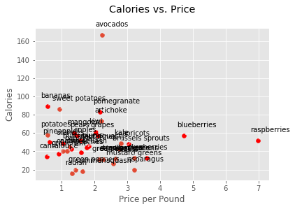

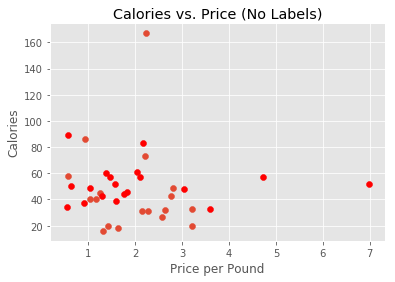

```python
#Plot Calories vs. Price
plt.scatter(final.iloc[0:18,1], final.iloc[0:18,8])
plt.scatter(final.iloc[19:38,1], final.iloc[19:38,8], c = 'r')
plt.xlabel("Price per Pound")
plt.ylabel("Calories")
plt.title("Calories vs. Price\n")

labels = final['food name']

for label, x, y in zip(labels, final.iloc[:,1], final.iloc[:,8]):
    plt.annotate(
        label,
        xy=(x, y), xytext=(-10, 10),
        textcoords='offset points', ha='left', va='bottom',
        arrowprops=dict(arrowstyle = '->', connectionstyle='arc3,rad=0'))

plt.show()


#Plot Calories vs. Price
plt.scatter(final.iloc[0:18,1], final.iloc[0:18,8])
plt.scatter(final.iloc[19:38,1], final.iloc[19:38,8], c = 'r')
plt.xlabel("Price per Pound")
plt.ylabel("Calories")
plt.title("Calories vs. Price (No Labels)")

plt.show()
```

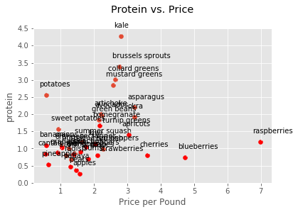

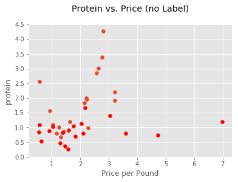

```python
#Plot Protein vs price
plt.scatter(final.iloc[0:18,1], final.iloc[0:18,9])
plt.scatter(final.iloc[19:38,1], final.iloc[19:38,9], c = 'r')
plt.xlabel("Price per Pound")
plt.ylabel("protein")
plt.title("Protein vs. Price\n")

labels = final['food name']

for label, x, y in zip(labels, final.iloc[:,1], final.iloc[:,9]):
    plt.annotate(
        label,
        xy=(x, y), xytext=(-10, 10),
        textcoords='offset points', ha='left', va='bottom',
        arrowprops=dict(arrowstyle = '->', connectionstyle='arc3,rad=0'))

plt.show()

#Plot Protein vs price no label
plt.scatter(final.iloc[0:18,1], final.iloc[0:18,9])
plt.scatter(final.iloc[19:38,1], final.iloc[19:38,9], c = 'r')

plt.xlabel("Price per Pound")
plt.ylabel("protein")
plt.title("Protein vs. Price (no Label)\n")

plt.show()
```

The next graph, yeild vs protein, tells a similar story to the previous graphs, but this time artichoke's lower yeild causes it to fall in value compared to the greens and brussels.

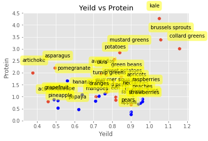

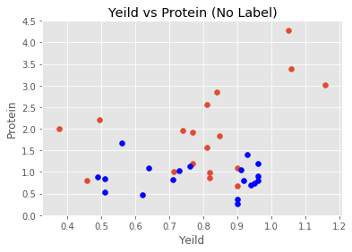

```python
#Plot Yeild vs protein
plt.scatter(final.iloc[0:18,2], final.iloc[0:18,9])
plt.scatter(final.iloc[19:38,2], final.iloc[19:38,9], c = 'b')
plt.xlabel("Yeild")
plt.ylabel("Protein")
plt.title("Yeild vs Protein")

labels = final['food name']

for label, x, y in zip(labels, final.iloc[:,2], final.iloc[:,9]):
    plt.annotate(
        label,
        xy=(x, y), xytext=(-20, 20),
        textcoords='offset points', ha='left', va='bottom',
        bbox=dict(boxstyle='round,pad=0.5', fc='yellow', alpha=0.5),
        arrowprops=dict(arrowstyle = '->', connectionstyle='arc3,rad=0'))

plt.show()

#Plot Yeild vs protein no Label
plt.scatter(final.iloc[0:18,2], final.iloc[0:18,9])
plt.scatter(final.iloc[19:38,2], final.iloc[19:38,9], c = 'b')
plt.xlabel("Yeild")
plt.ylabel("Protein")
plt.title("Yeild vs Protein (No Label)")
```

The last two graphs shows avocado to have a high value in terms of yeild and calories. We see that although collard greens and brussels have high protein, they do not have very high calories in each yeild.

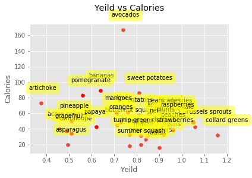

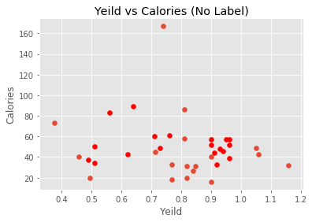

```python
#Plot Yeild v calories
plt.scatter(final.iloc[0:18,2], final.iloc[0:18,8])
plt.scatter(final.iloc[19:38,2], final.iloc[19:38,8], c = 'r')
plt.xlabel("Yeild")
plt.ylabel("Calories")
plt.title("Yeild vs Calories\n")

labels = final['food name']

for label, x, y in zip(labels, final.iloc[:,2], final.iloc[:,8]):
    plt.annotate(
        label,
        xy=(x, y), xytext=(-20, 20),
        textcoords='offset points', ha='left', va='bottom',
        bbox=dict(boxstyle='round,pad=0.5', fc='yellow', alpha=0.5),
        arrowprops=dict(arrowstyle = '->', connectionstyle='arc3,rad=0'))

plt.show()


#Plot Yeild v calories
plt.scatter(final.iloc[0:18,2], final.iloc[0:18,8])
plt.scatter(final.iloc[19:38,2], final.iloc[19:38,8], c = 'r')
plt.xlabel("Yeild")
plt.ylabel("Calories")
plt.title("Yeild vs Calories (No Label)")


plt.show()
```